# Gathering Data from Websites Using `R` Programming language

Scrapping Premier Spanish Soccer League Data

John Karuitha

Saturday, October 02, 2021

## **Background**

Have you ever come across some valuable data on a website and wished to access and use it in your research? Did you get discouraged from using data from the internet because writing down the data by hand and transferring it to a spreadsheet seemed daunting? Have you ever spent a substantial amount of time trying to copy and paste data from a website with plenty of frustration and headache? If you have found yourself in any of these and similar situations, this write-up is for you. I will describe the basics of harvesting data from websites, commonly known as web scraping, using the `R` (R Core Team 2021) programming language. I start with tabular data that most financial analysts, economists, and other business professionals and academics use on many occasions. In future articles, I will delve deeper into scrapping websites for text and different data types. The basics in this section should meet the needs of most users but watch out for more advanced applications of web scraping on my blog and `rpubs`.

The author is at Karatina University, School of Business, P.O. Box 1957-10101, Karatina, Kenya.

The R code for this project is available in my GitHub account on this link https://github.com/Karuitha/scrapping_la_liga/blob/master/code/scraps.R. Copy and paste the address on a new browser tab

R Core Team. 2021. *R: A Language and Environment for Statistical Computing*. Vienna, Austria: R Foundation for Statistical Computing. https://www.R-project.org/.

## **The Target Website and Data**

I have conveniently chosen the results of the premier soccer league in Spain, the `La Liga`. The data comes from two sources. The first source is [wikipedia](https://en.wikipedia.org/wiki/List_of_Spanish_football_champions). On this site, we shall scrap data regarding the results of the Spanish La Liga from 1929 to 2021. The site gives the top 3 teams over the years together with the names of top scorers.. The second source is [sky news](https://www.skysports.com/la-liga-table/). This second source provides results of the more recent La Liga results starting 2009 to 2021. I use this site to illustrate how to scrap data that spans multiple web pages..

You can view this page on this address https://en.wikipedia.org/wiki/List_of_Spanish_football_champions

Again, you can view this data on this address https://www.skysports.com/la-liga-table/

## **Objectives and Caveats**

In this article, I aim to;

1. Demonstrate the basics of scrapping data tables from a website using `R` and the `rvest` package from the `tidyverse`.
2. Clean the data tables to generate an actionable set of data.

In my analysis, I assume basic knowledge of the `R` programming language and regular expressions (`Regex`). Moreover, my article aims mainly at demonstrating web scrapping and not the analysis of the data. However, I do a bit of data cleaning because it is a natural extension of web scrapping. Most data acquired through web scrapping is rarely clean and hence requires a substantial amount of pre-processing to be useful for analysis. Finally, this project targets a general audience that may not appreciate the academic nuances of inserting citations at the end of a sentence. However, I do include the references as side notes to the main text.

## **Practical, Ethical and Legal Considerations in Web-Scraping**

As in every other activity, it is essential to make ethical considerations when harvesting data from the internet. Ethics in garnering data from the internet is especially pertinent with the increase in online criminal activity (Krotov and Silva 2018). Several issues are important in this respect.

Krotov, Vlad, and Leiser Silva. 2018. “Legality and Ethics of Web Scraping.”

- If there is an API allowing one to download data directly, it is much simpler to use it than web scraping. This API matter is a practical consideration; do not waste your time.
- Some websites, like Amazon, have a policy prohibiting web scraping. It would not be safe to against this policy as it has legal implications. Always read the terms of use before scraping data from any website.
- When scraping many web pages, the website owners may mistake it for a denial of service (DoS) attack. It is always safe to include a piece of code to pause your scrapper. For instance, you could write code to wait for 5 seconds after each page before resuming the scraping.

*NB: Just because you can do web scraping does not mean you must do it.*

## **Web Scrapping Intuition**

It is important to grasp XML, HTML, and CSS fundamentals to appreciate the basics of web-scrapping in any programming language. Starting with William W. Tunnicliffe’s presentation in 1967, markup languages have evolved into various forms to suit different applications. Examples include TeX, HTML, XML, and XHTML. I highlight XML and HTML and how we can take advantage of each to identify relevant content (Ramasubramanian and Singh 2017).

Ramasubramanian, Karthik, and Abhishek Singh. 2017. *Machine Learning Using r*. 1. Springer.

### *XML Tags*

Markup languages have two basic constructs;

- Tags.
- Content.

A tag usually begins with < and ends with a >. The tags come in three flavours.

- Start tags: `<student_name>`. This tag marks the start of the content.
- End tags: `</student_name>`. This tag marks the end of the content.
- Empty tags: </>.

The wording in between the < and > is the identifier of the content. In between the beginning and ending tags, we include our content. For instance, we could capture an employee’s name using the following markup code.

`<employee_name> james Peter Onyango Kamau </employee_name>`

Hence, we can use the marker employee_name to identify the content we want to capture. We now extend the same idea to HTML.

### *HTML*

The Hypertext Markup Language (HTML) is the language that programmers use to create web pages. Usually, HTML combines well with CSS to create elegant web pages. To scrap web pages for data, we have to scan for the following five elements (Bradley and James 2019).

Bradley, Alex, and Richard JE James. 2019. “Web Scraping Using r.” *Advances in Methods and Practices in Psychological Science* 2 (3): 264–70.

- Headers; We construct an HTML header as follows.
- Headings;

Commonly, there are six headers h1 to h6, as follows (Michaud 2013).

Michaud, Thomas. 2013. *Foundations of Web Design: Introduction to HTML & CSS*. New Riders.

`<h1> Header 1 </h1>`

`<h2> Header 2 </h2>`

`<h3> Header 3 </h3>`

`<h4> Header 4 </h4>`

`<h5> Header 5 </h5>`

`<h6> Header 6 </h6>`

- Paragraphs; A paragraph usually has a tag `p`.

`<p> Paragraph 1 </p>`

`<p> Paragraph 2 </p>`

- Tables; This is the focus of this article. In HTML, tags for tables are as follows.

`<table>` tag that captures the main table structure.

`<tbody>` tag that specifies the body of the table.

`<thead>` tag that specifies the table header.

`<tr>` tag that specifies each of the rows of the table.

- Anchors; Anchors allow web developers to attach an URL to some text on a web page. Viewers can then click on the text to activate the link and visit the page. An example of an anchor is as follows (Macaulay 2017).

  Macaulay, Michael. 2017. *Introduction to Web Interaction Design: With HTML and CSS*. Chapman; Hall/CRC.

`<a href="https://rpubs.com/Karuitha/karuitha_cars_pressure"> Click to see my project </a>`

## **Part A: Scraping Data from a Webpage**

In this section, I highlight how one can get data from a webpage. As noted earlier, I use the Wikipedia site. The data of interest is tabular. The steps in scraping this data using the `rvest` (Wickham 2021) package in `R` are as follows (Wickham et al. 2019).

Wickham, Hadley. 2021. *Rvest: Easily Harvest (Scrape) Web Pages*. https://CRAN.R-project.org/package=rvest.

Wickham, Hadley, Mara Averick, Jennifer Bryan, Winston Chang, Lucy D’Agostino McGowan, Romain François, Garrett Grolemund, et al. 2019. “Welcome to the tidyverse.” *Journal of Open Source Software* 4 (43): 1686. https://doi.org/10.21105/joss.01686.

- First, read in the web address, using the `read_html` function.
- Capture the HTML nodes that point to tables using the `html_nodes` function and specifying `table`.
- Extract the tables. Here, use the `html_table` function. Note that this page has many tables.
- Get the table of interest. Here, you subset the list using square brackets, `[[a]]`.
- Clean the data to suit your analysis needs.

The code below reproduces these steps.

Because the dataset is massive, I only present the first ten rows of the data. Please scroll right or left to view the entire set of variables in the table (Mailund 2017).

Mailund, Thomas. 2017. *Beginning Data Science in r*. Springer.

```r
url2 <- "https://en.wikipedia.org/wiki/List_of_Spanish_football_champions"

read_html(url2) %>%

        ## Capture the nodes for tables
        html_nodes("table") %>%

        ## Capture the tables
        html_table() %>%

        ## Capture the third table in the series
        .[[3]] %>%

        ## Remove square brackets in names
        set_names(names(.) %>% str_remove_all("\\[|\\]|\\d")) %>%

        ## Clean names by removing spaces
        janitor::clean_names() %>%

        ## Remove redundant columns
        select(-starts_with("x")) %>%

        ## Clean the team names
        mutate(winners = str_remove_all(winners, "\\(\\d+\\)|\\*")) %>%

        ## Pick the top 10
        head(10) %>%

        ## make a nice table
        knitr::kable()
```

| season | winners | runners_up | third_place | top_scorer_s | top_scorers_club_s | goals |
| --- | --- | --- | --- | --- | --- | --- |
| 1929 | Barcelona | Real Madrid (1) | Athletic Bilbao | Paco Bienzobas | Real Sociedad | 14 |
| 1929–30 | Athletic Bilbao | Barcelona (1) | Arenas | Guillermo Gorostiza | Athletic Bilbao | 19 |
| 1930–31 | Athletic Bilbao | Racing Santander (1) | Real Sociedad | Bata | Athletic Bilbao | 27 |
| 1931–32 | Real Madrid | Athletic Bilbao (1) | Barcelona | Guillermo Gorostiza | Athletic Bilbao | 12 |
| 1932–33 | Real Madrid | Athletic Bilbao (2) | Espanyol | Manuel Olivares | Real Madrid | 16 |
| 1933–34 | Athletic Bilbao | Real Madrid (2) | Racing Santander | Isidro Lángara | Oviedo | 27 |
| 1934–35 | Real Betis | Real Madrid (3) | Oviedo | Isidro Lángara | Oviedo | 26 |
| 1935–36 | Athletic Bilbao | Real Madrid (4) | Oviedo | Isidro Lángara | Oviedo | 27 |
| 1936–37 | Spanish Civil War (League Cancelled) | Spanish Civil War (League Cancelled) | Spanish Civil War (League Cancelled) | Spanish Civil War (League Cancelled) | Spanish Civil War (League Cancelled) | Spanish Civil War (League Cancelled) |
| 1937–38 | Spanish Civil War (League Cancelled) | Spanish Civil War (League Cancelled) | Spanish Civil War (League Cancelled) | Spanish Civil War (League Cancelled) | Spanish Civil War (League Cancelled) | Spanish Civil War (League Cancelled) |

I follow the same steps on the sky news website to generate the La Liga standings for the 2020-2021 season.

```r
#########################################
## PART 2: SCRAPPING ONE WEB PAGE

## Initial trial with one url for 2020/2021 season

## Define the url

url <- "https://www.skysports.com/la-liga-table/2020"

## Read the html
read_html(url) %>%

        ## Capture the nodes for tables
        html_nodes("table") %>%

        ## Capture the tables
        html_table() %>%

        ## Capture the first table in the series
        .[[1]] %>%

        ## rename the position column
        rename(pos = `#`) %>%

        ## Clean the column names
        janitor::clean_names() %>%

        ## Remove redundant last 6 column
        select(-last_6) %>%

        ## make a nice table
        knitr::kable(caption = "La Liga Standings 2020-2021 Season")
```

La Liga Standings 2020-2021 Season

| pos | team | pl | w | d | l | f | a | gd | pts |
| --- | --- | --- | --- | --- | --- | --- | --- | --- | --- |
| 1 | Atletico Madrid | 38 | 26 | 8 | 4 | 67 | 25 | 42 | 86 |
| 2 | Real Madrid | 38 | 25 | 9 | 4 | 67 | 28 | 39 | 84 |
| 3 | Barcelona | 38 | 24 | 7 | 7 | 85 | 38 | 47 | 79 |
| 4 | Sevilla | 38 | 24 | 5 | 9 | 53 | 33 | 20 | 77 |
| 5 | Real Sociedad | 38 | 17 | 11 | 10 | 59 | 38 | 21 | 62 |
| 6 | Real Betis | 38 | 17 | 10 | 11 | 50 | 50 | 0 | 61 |
| 7 | Villarreal | 38 | 15 | 13 | 10 | 60 | 44 | 16 | 58 |
| 8 | Celta Vigo | 38 | 14 | 11 | 13 | 55 | 57 | -2 | 53 |
| 9 | Granada | 38 | 13 | 7 | 18 | 47 | 65 | -18 | 46 |
| 10 | Athletic Bilbao | 38 | 11 | 13 | 14 | 46 | 42 | 4 | 46 |
| 11 | Osasuna | 38 | 11 | 11 | 16 | 37 | 48 | -11 | 44 |
| 12 | Cadiz | 38 | 11 | 11 | 16 | 36 | 58 | -22 | 44 |
| 13 | Valencia | 38 | 10 | 13 | 15 | 50 | 53 | -3 | 43 |
| 14 | Levante | 38 | 9 | 14 | 15 | 46 | 57 | -11 | 41 |
| 15 | Getafe | 38 | 9 | 11 | 18 | 28 | 43 | -15 | 38 |
| 16 | Alaves | 38 | 9 | 11 | 18 | 36 | 57 | -21 | 38 |
| 17 | Elche | 38 | 8 | 12 | 18 | 34 | 55 | -21 | 36 |
| 18 | SD Huesca | 38 | 7 | 13 | 18 | 34 | 53 | -19 | 34 |
| 19 | Real Valladolid | 38 | 5 | 16 | 17 | 34 | 57 | -23 | 31 |
| 20 | Eibar | 38 | 6 | 12 | 20 | 29 | 52 | -23 | 30 |

```r
#########################################
```

So far, so good.

## **Part B: Scraping Data from Multiple Webpages**

What happens when the data of interest spans multiple pages of a website? For instance, in the Sky News website for the La Liga results, each season has its page. However, the pagination follows a consistent pattern as follows.

- For the 2020/21 season: https://www.skysports.com/la-liga-table/2020
- For the 2019/20 season: https://www.skysports.com/la-liga-table/2019
- Hence, for the nth season: https://www.skysports.com/la-liga-table/n

Hence, we can generate web addresses that match the seasons we are targeting. We shall revisit this critical issue in a moment. First, I write a function that will allow us to scrap a website when provided with a URL.

This reminds me of Kenya’s President Uhuru Kenyatta’s promise to “revisit” the judiciary. Both parties are now busy reviewing each other.

```r
#########################################
## PART 3: SCRAP MULTIPLE WEB PAGES

# Scrap the 12 links of the results from 2009 to 2021.

# NB: Every page starts with "https://www.skysports.com/la-liga-table/"

# Then for every respective year, the year is appended.

# For instance for 2020, the address is "https://www.skysports.com/la-liga-table/2020"

## Write a scrapping function

scrapper <- function(url){

        ## Add delay after scrapping each page
        Sys.sleep(2)

        ## Read the html
        read_html(url) %>%

                ## Capture the nodes for tables
                html_nodes("table") %>%

                ## Capture the tables
                html_table() %>%

                ## Capture the first table in the series
                .[[1]] %>%

                ## rename the position column
                rename(pos = `#`) %>%

                ## Clean the column names
                janitor::clean_names() %>%

                ## Remove redundant last 6 column
                select(-last_6)
}

##########################################
```

The following code generates the web addresses on the Sky News website that correspond to the seasons from 2009 to 2020. Notice now we have all the URLs.

```r
##########################################
## Capture all the urls for years 2009-2021

many_urls <- paste0("https://www.skysports.com/la-liga-table/", 2020:2009)

many_urls
```

```
##  [1] "https://www.skysports.com/la-liga-table/2020"
##  [2] "https://www.skysports.com/la-liga-table/2019"
##  [3] "https://www.skysports.com/la-liga-table/2018"
##  [4] "https://www.skysports.com/la-liga-table/2017"
##  [5] "https://www.skysports.com/la-liga-table/2016"
##  [6] "https://www.skysports.com/la-liga-table/2015"
##  [7] "https://www.skysports.com/la-liga-table/2014"
##  [8] "https://www.skysports.com/la-liga-table/2013"
##  [9] "https://www.skysports.com/la-liga-table/2012"
## [10] "https://www.skysports.com/la-liga-table/2011"
## [11] "https://www.skysports.com/la-liga-table/2010"
## [12] "https://www.skysports.com/la-liga-table/2009"
```

```r
########################################
```

Now, we run a loop over all URLs using the function defined earlier. The results are in the appendix.

```r
#######################################
## Run a loop over all the web pages

la_liga_09_2020 <- lapply(many_urls, scrapper)

## Give each table a name corresponding to the year

names(la_liga_09_2020) <- paste0("year", 2020:2009)

##########################################
```

## **Basic Data Exploration**

In this section, I do some data exploration using the La Liga data from 2009-2021. My question is, which team has won the most La Liga trophies over these seasons (2009-2021)? The visualization below tells it all.

```r
##########################################
## Get the top team in each year

top_teams_2009_20 <- sapply(la_liga_09_2020, "[", 1, "team") %>%

        ## Unlist to make one table
        unlist() %>%

        ## Coerce to tibble
        tibble() %>%

        ## Rename column
        rename(team = ".")

################################################################################
```

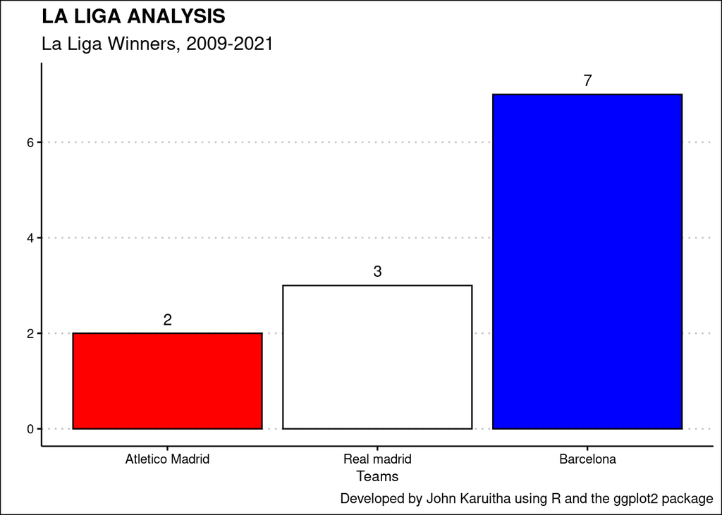

```r
################################################################################
## Capture the top teams
top_teams_2009_20 %>%

        ## make a table

        table() %>%

        ## Convert table into tibble

        tibble() %>%

        ## Rename the tibble column

        rename(no = ".") %>%

        ## Add team names

        mutate(team = c("Atletico Madrid", "Barcelona", "Real madrid")) %>%

        ## Convert teams to factors

        mutate(team = factor(team)) %>%

        ## Relocate team column to first position

        relocate(team) %>%

        ## Plot the data

        ggplot(aes(x = fct_reorder(team, no), y = no, fill = team)) +

        ## Add a geom

        geom_col(col = "black", show.legend = FALSE) +

        ## Add text labels

        geom_text(aes(label = no), nudge_y = 0.3) +

        ## Add x and y labels and a title, subtitle

        labs(x = "Teams", y = "", title = "LA LIGA ANALYSIS",

             subtitle = "La Liga Winners, 2009-2021",

             caption = "Developed by John Karuitha using R and the ggplot2 package") +

        ## Select bar colors

        scale_fill_manual(values = c("red", "blue", "white")) +

        ## Add a pleasant theme

        ggthemes::theme_clean()
```

```r
############################################
```

## **Conclusion**

Web scraping is a valuable skill in every researcher’s toolkit, more so with the rise of social media research. However, most scrapped data can be messy and may require substantial effort cleaning. In this write-up, I used `R` to demonstrate web scrapping. Other programming languages like `Python` do offer the same capabilities.

## **Appendix**

### Appendix 1: la Liga Standings 2009-2021

```r
############################################

## Appendix: The full list of data scrapped

la_liga_09_2020
```

```
## $year2020
## # A tibble: 20 × 10
##      pos team               pl     w     d     l     f     a    gd   pts
##    <int> <chr>           <int> <int> <int> <int> <int> <int> <int> <int>
##  1     1 Atletico Madrid    38    26     8     4    67    25    42    86
##  2     2 Real Madrid        38    25     9     4    67    28    39    84
##  3     3 Barcelona          38    24     7     7    85    38    47    79
##  4     4 Sevilla            38    24     5     9    53    33    20    77
##  5     5 Real Sociedad      38    17    11    10    59    38    21    62
##  6     6 Real Betis         38    17    10    11    50    50     0    61
##  7     7 Villarreal         38    15    13    10    60    44    16    58
##  8     8 Celta Vigo         38    14    11    13    55    57    -2    53
##  9     9 Granada            38    13     7    18    47    65   -18    46
## 10    10 Athletic Bilbao    38    11    13    14    46    42     4    46
## 11    11 Osasuna            38    11    11    16    37    48   -11    44
```

[output cut: 284 more lines]

```r
############################################
```

## Appendix 2: La Liga Top 3 Teams and Top Scorers 1929-2021

| season | winners | runners_up | third_place | top_scorer_s | top_scorers_club_s | goals |
| --- | --- | --- | --- | --- | --- | --- |
| 1929 | Barcelona | Real Madrid (1) | Athletic Bilbao | Paco Bienzobas | Real Sociedad | 14 |
| 1929–30 | Athletic Bilbao | Barcelona (1) | Arenas | Guillermo Gorostiza | Athletic Bilbao | 19 |
| 1930–31 | Athletic Bilbao | Racing Santander (1) | Real Sociedad | Bata | Athletic Bilbao | 27 |
| 1931–32 | Real Madrid | Athletic Bilbao (1) | Barcelona | Guillermo Gorostiza | Athletic Bilbao | 12 |
| 1932–33 | Real Madrid | Athletic Bilbao (2) | Espanyol | Manuel Olivares | Real Madrid | 16 |
| 1933–34 | Athletic Bilbao | Real Madrid (2) | Racing Santander | Isidro Lángara | Oviedo | 27 |
| 1934–35 | Real Betis | Real Madrid (3) | Oviedo | Isidro Lángara | Oviedo | 26 |
| 1935–36 | Athletic Bilbao | Real Madrid (4) | Oviedo | Isidro Lángara | Oviedo | 27 |
| 1936–37 | Spanish Civil War (League Cancelled) | Spanish Civil War (League Cancelled) | Spanish Civil War (League Cancelled) | Spanish Civil War (League Cancelled) | Spanish Civil War (League Cancelled) | Spanish Civil War (League Cancelled) |
| 1937–38 | Spanish Civil War (League Cancelled) | Spanish Civil War (League Cancelled) | Spanish Civil War (League Cancelled) | Spanish Civil War (League Cancelled) | Spanish Civil War (League Cancelled) | Spanish Civil War (League Cancelled) |
| 1938–39 | Spanish Civil War (League Cancelled) | Spanish Civil War (League Cancelled) | Spanish Civil War (League Cancelled) | Spanish Civil War (League Cancelled) | Spanish Civil War (League Cancelled) | Spanish Civil War (League Cancelled) |
| 1939–40 | Atlético Aviación[a] | Sevilla (1) | Athletic Bilbao | Víctor Unamuno | Athletic Bilbao | 22 |
| 1940–41 | Atlético Aviación[a] | Athletic Bilbao (3) | Valencia | Pruden | Atlético Aviación | 30 |
| 1941–42 | Valencia | Real Madrid (5) | Atlético Aviación | Edmundo Suárez | Valencia | 27 |
| 1942–43 | Athletic Bilbao | Sevilla (2) | Barcelona | Mariano Martín | Barcelona | 32 |
| 1943–44 | Valencia | Atlético Aviación (1) | Sevilla | Edmundo Suárez | Valencia | 27 |
| 1944–45 | Barcelona | Real Madrid (6) | Atlético Aviación | Telmo Zarra | Atlético Bilbao | 19 |
| 1945–46 | Sevilla | Barcelona (2) | Athletic Bilbao | Telmo Zarra | Atlético Bilbao | 24 |
| 1946–47 | Valencia | Athletic Bilbao (4) | Atlético Aviación | Telmo Zarra | Atlético Bilbao | 34 |
| 1947–48 | Barcelona | Valencia (1) | Atlético Madrid | Pahiño | Celta Vigo | 23 |
| 1948–49 | Barcelona | Valencia (2) | Real Madrid | César Rodríguez Álvarez | Barcelona | 28 |
| 1949–50 | Atlético Madrid | Deportivo La Coruña (1) | Valencia | Telmo Zarra | Athletic Bilbao | 25 |
| 1950–51 | Atlético Madrid | Sevilla (3) | Valencia | Telmo Zarra | Athletic Bilbao | 38 |
| 1951–52 | Barcelona | Athletic Bilbao (5) | Real Madrid | Pahiño | Real Madrid | 28 |
| 1952–53 | Barcelona | Valencia (3) | Real Madrid | Telmo Zarra | Athletic Bilbao | 24 |
| 1953–54 | Real Madrid | Barcelona (3) | Valencia | Alfredo Di Stéfano | Real Madrid | 27 |
| 1954–55 | Real Madrid | Barcelona (4) | Athletic Bilbao | Juan Arza | Sevilla | 28 |
| 1955–56 | Athletic Bilbao | Barcelona (5) | Real Madrid | Alfredo Di Stéfano | Real Madrid | 24 |
| 1956–57 | Real Madrid † | Sevilla (4) | Barcelona | Alfredo Di Stéfano | Real Madrid | 31 |
| 1957–58 | Real Madrid † | Atlético Madrid (2) | Barcelona | Manuel BadenesAlfredo Di StéfanoRicardo | ValladolidReal MadridValencia | 19 |

[output cut: 63 more lines]